# Model lasu losowego na danych ankietowych - część 2

Bartosz Dąbrowski

30 05 2020

# Wczytanie danych

Import przygotowanych danych i delikatne zmiany.

Na potrzeby modelu, usunąć należy kolumny bez zdolności predykcyjnej - sygnaturę czasową, dobrowolny feedback oraz pytanie o miejsce zamieszkanie w trakcie studiów, które zostało już rozbite na 5 zmiennych zero-jedynkowych.

Dla większej czytelności zmieniono nazwy kolumn.

```
##  [1] "Kobieta"                 "Wiek"
##  [3] "Wojewodztwo_pochodzenia" "Wielkosc_miasta"
##  [5] "Miasto"                  "Wiecej_kierunkow"
##  [7] "Rok"                     "Prywatna"
##  [9] "Zaocznie"                "Typ"
## [11] "Kola"                    "Organizacje"
## [13] "Samorzad"                "Srednia"
## [15] "Stypendium"              "Wiodace"
## [17] "Zapychacze"              "Zapychacze_dobor"
## [19] "Jezyk"                   "Organizacja_uczelni"
## [21] "Plany"                   "Trudnosc"
## [23] "Przydatnosc"             "Ogolna_ocena"
## [25] "Praca"                   "Akademik"
## [27] "Dom_mieszkanie_rodzinne" "Wynajete_mieszkanie"
## [29] "Wynajety_pokoj"          "Inne"
## [31] "Dyscyplina"
```

# MODELE

```
##
## Call:
##  randomForest(formula = Praca ~ ., data = df, ntree = 1000, mtry = 5,      importance = TRUE)
##                Type of random forest: classification
##                      Number of trees: 1000
## No. of variables tried at each split: 5
##
##         OOB estimate of  error rate: 29.06%
## Confusion matrix:
##     0  1 class.error
## 0 210 48   0.1860465
## 1  72 83   0.4645161
```

```
##                                  0           1 MeanDecreaseAccuracy
## Kobieta                 -1.2297222 -0.03040266           -0.9048285
## Wiek                    15.9850065  9.07906787           18.0539607
## Wojewodztwo_pochodzenia  8.7489840 -3.51083447            4.7939705
## Wielkosc_miasta          3.2408717 -0.88692454            2.0967935
## Miasto                   6.3142580 -4.90811629            2.0521389
## Wiecej_kierunkow        -2.0553480 -1.02294912           -1.9838581
## Rok                     12.7464189  7.63574857           15.3408012
## Prywatna                -0.2720738 -2.76311291           -2.3511522
## Zaocznie                15.1763757  9.82736233           16.6212013
## Typ                      1.3635271 -0.03083502            1.0529941
## Kola                    -2.9152208  0.92614022           -1.5716125
## Organizacje              0.4227010  0.07037256            0.3720740
## Samorzad                -1.6817845 -0.33450815           -1.4123596
## Srednia                  2.0722593 -0.26812193            1.4108278
## Stypendium               7.3070509  3.87319620            8.0422854
## Wiodace                 -1.5258344 -0.24775067           -1.4050039
## Zapychacze               0.1748410 -1.16234142           -0.6246228
## Zapychacze_dobor        -2.6822092  3.07111919           -0.4358110
## Jezyk                    1.6678548 -0.28565299            1.2608771
## Organizacja_uczelni     -0.3520253 -0.69285036           -0.6506117
## Plany                    0.6248878  3.51778325            2.6425347
## Trudnosc                 7.7443964  2.53193764            7.5843911
## Przydatnosc              1.1081339 -0.45889719            0.6033660
## Ogolna_ocena            -0.0248981  0.40589160            0.2909102
## Akademik                 3.0715559 -0.66593586            2.1606203
## Dom_mieszkanie_rodzinne -0.8616137 -1.16787174           -1.4787052
## Wynajete_mieszkanie     -0.9735925 -2.36914624           -2.1209436
## Wynajety_pokoj           1.9402551 -0.75617926            1.1303437
## Inne                    -1.7379123 -3.08657705           -3.0089613
## Dyscyplina              14.4139284 16.70733874           20.6513254
##                         MeanDecreaseGini
## Kobieta                        2.6360207
## Wiek                          14.3303739
## Wojewodztwo_pochodzenia       21.0073383
## Wielkosc_miasta                9.7828385
## Miasto                        17.9944322
## Wiecej_kierunkow               0.6984184
## Rok                           13.9390090
## Prywatna                       0.7506872
## Zaocznie                       5.1542128
## Typ                            5.5137790
## Kola                           2.1210461
## Organizacje                    1.4836948
## Samorzad                       1.6136936
## Srednia                        5.9381768
## Stypendium                     3.7222781
## Wiodace                        4.9790137
## Zapychacze                     5.6604474
## Zapychacze_dobor               6.5427395
## Jezyk                          6.7570981
## Organizacja_uczelni            6.1407533
## Plany                          6.5840808
## Trudnosc                       7.8605262
## Przydatnosc                    6.1735837
## Ogolna_ocena                   5.2880665
## Akademik                       1.9224086
## Dom_mieszkanie_rodzinne        2.2841551
## Wynajete_mieszkanie            2.3117065
## Wynajety_pokoj                 2.4630087
## Inne                           0.5062729
## Dyscyplina                    20.1211597
```

Wykres modelu przedstawia kształtowanie się błędu poza próbką w raz ze wzrostem liczby drzew. Po gwałtownym zmniejszaniu do około 200, następuje stablizacja. Zielona linia oznacza błąd w klasyfikacji pracujących, czerwona - niepracujących, a czarna - uśredniony dla obu grup.

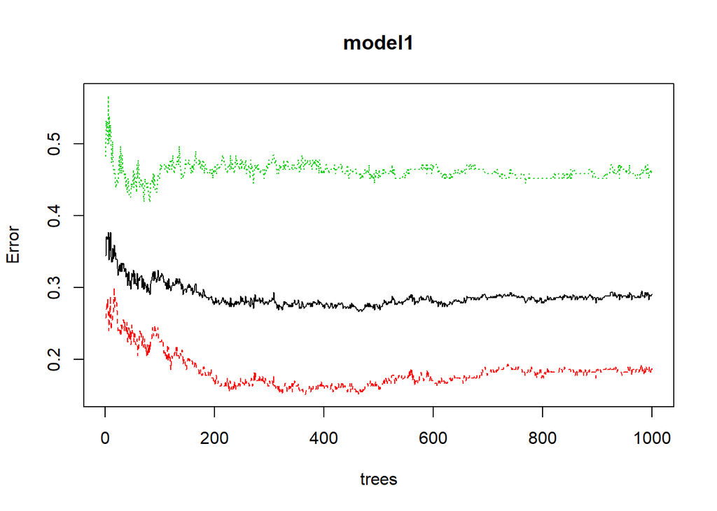

```
## AUC:  0.6747187
## OOB Error:  0.2905569
## Accuracy:  0.7094431
## Sensitivity:  0.8139535
## Specifity:  0.5354839
## G-Mean:  0.6601962
## Recall:  0.7446809
## Precision:  0.8139535
```

Pierwszy zbudowany model cechuje stosunkowa dobra dokładność - ponad 70%. Ma dość wysoką czułość kosztem niskiej swoistości - wiąże się to z dużo lepszym wykrywaniem bezrobotnych, podczas gdy skuteczność w przypadku pracujących wynosi niewiele ponad 50%. Najprawdopodobniej wpływ na to ma dysproporcja w próbkach. W następnym modelu zostaną one wyrównane.

## Model z wyrównanymi próbkami

```
##
## Call:
##  randomForest(formula = Praca ~ ., data = df, ntree = 1000, mtry = 5,      importance = TRUE, sampsize = c(155, 155))
##                Type of random forest: classification
##                      Number of trees: 1000
## No. of variables tried at each split: 5
##
##         OOB estimate of  error rate: 30.75%
## Confusion matrix:
##     0   1 class.error
## 0 182  76   0.2945736
## 1  51 104   0.3290323
```

```
##                                   0            1 MeanDecreaseAccuracy
## Kobieta                 -0.60775761 -1.303687925         -1.184931499
## Wiek                    11.18369381 12.539943410         16.281734422
## Wojewodztwo_pochodzenia  7.28518313 -1.435770493          5.645541645
## Wielkosc_miasta          0.56227733 -1.035663152         -0.034948989
## Miasto                   8.53895756 -3.417804120          5.837711588
## Wiecej_kierunkow        -0.33143249  0.607065739          0.045535419
## Rok                      8.65771774 11.603145944         14.253840619
## Prywatna                 0.65824385 -2.912722874         -1.164109610
## Zaocznie                10.77016454 10.522024486         14.021009400
## Typ                     -0.79071760 -0.775951375         -1.154796914
## Kola                    -2.43999425 -0.302635155         -2.156835258
## Organizacje             -1.44495233  1.061218820         -0.664851052
## Samorzad                -0.06113095 -1.167274390         -0.640503783
## Srednia                 -0.68293692 -0.221059793         -0.674561148
## Stypendium               4.82942410  5.159800464          6.805623904
## Wiodace                 -1.38315120 -0.379601635         -1.542452786
## Zapychacze              -2.44286744  2.092041601         -1.092727933
## Zapychacze_dobor        -3.70552517  2.704590352         -1.835297705
## Jezyk                    1.20112197  1.445343393          1.825361909
## Organizacja_uczelni     -0.59740168  0.373481346         -0.314990589
## Plany                   -0.50937528  3.836340760          1.880437272
## Trudnosc                 7.03661724  2.052185276          6.902555763
## Przydatnosc              0.86081468  1.498833545          1.620720790
## Ogolna_ocena            -0.41051530 -0.777822718         -0.807726540
## Akademik                 3.47078546  0.006288138          2.981498558
## Dom_mieszkanie_rodzinne -0.24897182 -0.964802925         -0.728132354
## Wynajete_mieszkanie      1.82778479 -1.273756234          0.849725935
## Wynajety_pokoj           0.25125109 -0.429257838         -0.001751644
## Inne                    -0.31748300 -1.794147141         -1.157259010
## Dyscyplina              10.90141665 16.455506354         17.592862847
##                         MeanDecreaseGini
## Kobieta                        2.0084081
## Wiek                          11.0126729
## Wojewodztwo_pochodzenia       17.5559360
## Wielkosc_miasta                7.9554163
## Miasto                        15.1219377
## Wiecej_kierunkow               0.5972224
## Rok                           11.4051656
## Prywatna                       0.6713159
## Zaocznie                       3.3302748
## Typ                            4.3395378
## Kola                           1.7284349
## Organizacje                    1.1536835
## Samorzad                       1.1614090
## Srednia                        4.8246788
## Stypendium                     3.0012220
## Wiodace                        4.0600116
## Zapychacze                     4.4413369
## Zapychacze_dobor               5.3300999
## Jezyk                          5.2329816
## Organizacja_uczelni            5.0802716
## Plany                          5.5417939
## Trudnosc                       5.8054834
## Przydatnosc                    4.6369760
## Ogolna_ocena                   4.0975369
## Akademik                       1.6854391
## Dom_mieszkanie_rodzinne        1.8114722
## Wynajete_mieszkanie            1.9058439
## Wynajety_pokoj                 1.9238889
## Inne                           0.4875901
## Dyscyplina                    16.4991735
```

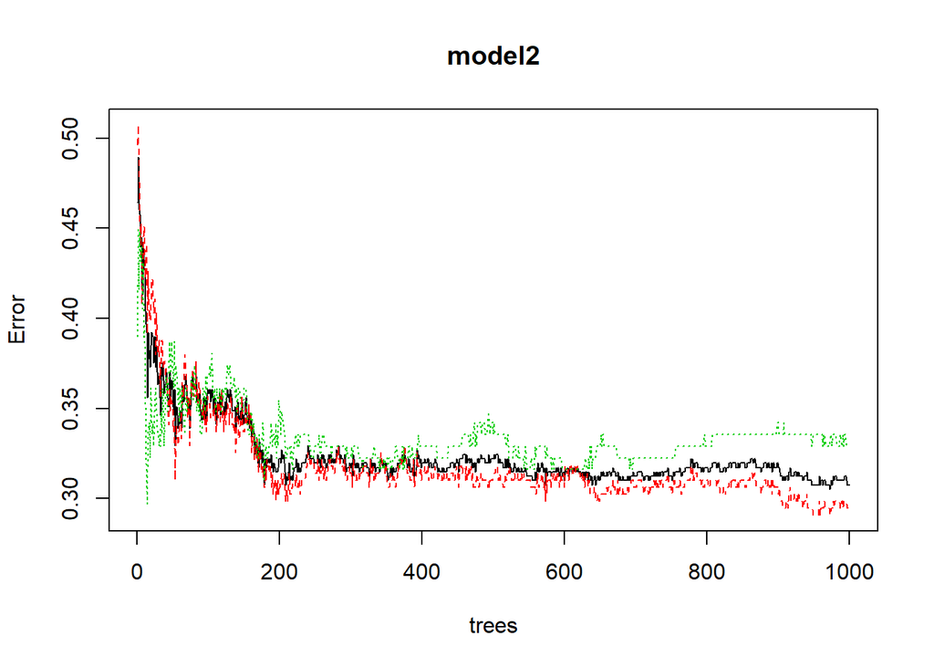

```
## AUC:  0.688197
## OOB Error:  0.3075061
## Accuracy:  0.6924939
## Sensitivity:  0.7054264
## Specifity:  0.6709677
## G-Mean:  0.6879813
## Recall:  0.7811159
## Precision:  0.7054264
```

Ogólna skuteczność uległa pogorszeniu. W zamian za to, wyrównaniu uległy czułość i swoistość, i model radzi sobie z klasyfikacją obu grup w podobnym stopniu. Pomimo nieco gorszych wyników, ma on większą wartość.

## PODZIAŁ NA DANE TESTOWE I TRENINGOWE

Po “testowych” modelach na całości danych, przyjęto wstępnie podział 70% dla danych uczących i 30% dla testowych.

```
##
##   0   1
## 182 107
```

```
##
## Call:
##  randomForest(formula = Praca ~ ., data = df_train, ntree = 1000,      mtry = 5, importance = TRUE, sampsize = c(104, 104))
##                Type of random forest: classification
##                      Number of trees: 1000
## No. of variables tried at each split: 5
##
##         OOB estimate of  error rate: 33.56%
## Confusion matrix:
##     0  1 class.error
## 0 125 57   0.3131868
## 1  40 67   0.3738318
```

```
##                                   0          1 MeanDecreaseAccuracy
## Kobieta                 -2.01388604 -2.0053528        -2.6417398894
## Wiek                     3.31335344  5.4611083         6.1354832647
## Wojewodztwo_pochodzenia  3.28853683 -1.9453090         1.9191641654
## Wielkosc_miasta          2.32221405 -1.4094901         1.2063863521
## Miasto                   5.40064571  0.2519955         4.7959852850
## Wiecej_kierunkow        -1.04436389 -0.7353429        -1.2508076274
## Rok                     -1.64018009  6.0728005         1.9675491052
## Prywatna                -0.17626688 -0.2979809        -0.2767719003
## Zaocznie                11.08648210 13.1643364        15.3535197120
## Typ                     -0.75019860  0.4234548        -0.3736478910
## Kola                    -3.98647210 -1.8376621        -4.3356418264
## Organizacje             -0.05809291 -0.3531852        -0.2464556018
## Samorzad                -0.97976366 -1.2498989        -1.5114280410
## Srednia                  1.76470698  3.1341065         3.1003854372
## Stypendium               3.72901535  6.7260578         6.7833408458
## Wiodace                 -0.30090014 -0.5892207        -0.5338227850
## Zapychacze              -4.76409512 -1.6187246        -5.1877599754
## Zapychacze_dobor        -4.88655398  0.6092164        -4.0006525342
## Jezyk                   -0.07194903 -0.7533474        -0.4682494684
## Organizacja_uczelni      2.55031902  1.4517807         2.9506496527
## Plany                    1.64884803  4.0643816         3.5967544051
## Trudnosc                 6.70690849  4.5556454         7.8702319634
## Przydatnosc              0.04669878 -2.1059225        -1.0984773142
## Ogolna_ocena            -1.20696161  1.0266797        -0.5482251992
## Akademik                 0.92806200  0.2064236         0.8767197657
## Dom_mieszkanie_rodzinne -2.42132265 -1.2163976        -2.4994394791
## Wynajete_mieszkanie      0.67944094  0.5926488         0.8398936704
## Wynajety_pokoj          -0.09593107  0.1202489        -0.0007428862
## Inne                     1.67350320 -2.6676917         0.1070288055
## Dyscyplina              11.61493860 15.9780264        17.3756439017
##                         MeanDecreaseGini
## Kobieta                        1.2203614
## Wiek                           6.0984624
## Wojewodztwo_pochodzenia       11.8825336
## Wielkosc_miasta                5.6979012
## Miasto                        10.6506779
## Wiecej_kierunkow               0.4587060
## Rok                            5.7118326
## Prywatna                       0.4754540
## Zaocznie                       3.2736005
## Typ                            3.1750867
## Kola                           1.1449029
## Organizacje                    0.7375862
## Samorzad                       0.8119971
## Srednia                        3.6491650
## Stypendium                     2.3333495
## Wiodace                        2.7557582
## Zapychacze                     2.7185973
## Zapychacze_dobor               3.1371692
## Jezyk                          3.5109356
## Organizacja_uczelni            3.2448929
## Plany                          4.0379886
## Trudnosc                       4.7397937
## Przydatnosc                    3.1158960
## Ogolna_ocena                   2.4882748
## Akademik                       1.0410109
## Dom_mieszkanie_rodzinne        1.2335935
## Wynajete_mieszkanie            1.2817577
## Wynajety_pokoj                 1.1454937
## Inne                           0.2641748
## Dyscyplina                    11.5415401
```

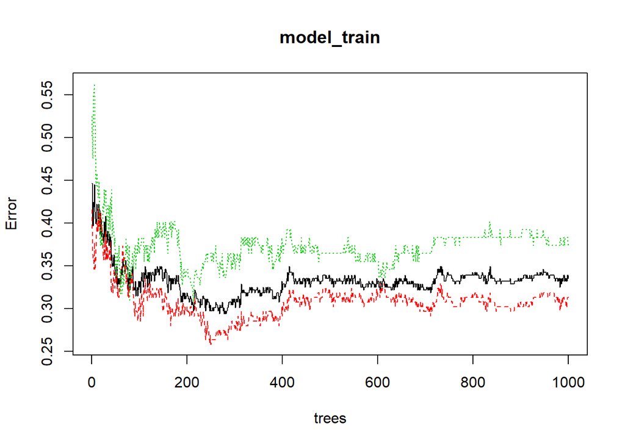

```
## AUC:  0.6348684
## OOB Error:  0.3629032
## Accuracy:  0.6370968
## Sensitivity:  0.7313433
## Specifity:  0.5263158
## G-Mean:  0.6204172
## Recall:  0.6447368
## Precision:  0.7313433
```

## Próba wykluczenia z modelu obserwacji o wątpliwej wiarygodności

Niektórzy z respondentów w pytaniu o feedback zgłaszali problemy z ankietą - najczęściej były to wątpliwości co do przypisania swojej uczelni bądź kierunku, niekiedy niepewność co do właściwego interpretowania swojej pracy - czy jest ona związana ze studiami. Do następnego modelu wykorzystane zostaną dane oczyszczone z takich obserwacji.

```
##
##   0   1
## 250 150
```

```
##
## Call:
##  randomForest(formula = Praca ~ ., data = df2, ntree = 1000, mtry = 5,      importance = TRUE, sampsize = c(150, 150))
##                Type of random forest: classification
##                      Number of trees: 1000
## No. of variables tried at each split: 5
##
##         OOB estimate of  error rate: 30.75%
## Confusion matrix:
##     0   1 class.error
## 0 177  73   0.2920000
## 1  50 100   0.3333333
```

```
##                                   0          1 MeanDecreaseAccuracy
## Wiek                    14.47595278 13.3836114           19.4660845
## Wojewodztwo_pochodzenia  7.53860468 -2.1318363            5.5355550
## Wielkosc_miasta          3.66976602 -1.2623619            2.4030808
## Miasto                   9.96814549 -0.2450514            8.6187809
## Wiecej_kierunkow         0.46057883 -2.0613098           -0.8449890
## Rok                     12.22971298 11.5254844           16.8814074
## Prywatna                 0.55813625 -1.5653795           -0.4439708
## Zaocznie                12.27099399  9.2373875           14.1793852
## Typ                     -0.90887261  1.0480898           -0.2624165
## Kola                    -2.12561745  0.2667910           -1.7371915
## Organizacje             -2.98109405 -0.5212178           -2.7184920
## Samorzad                -0.48113895 -0.6713455           -0.8149524
## Srednia                  1.13041397 -0.7821714            0.5092150
## Stypendium               6.71241723  6.0255162            8.7321529
## Wiodace                 -0.64143173  0.6593830           -0.2554688
## Zapychacze_dobor        -2.57574560 -0.1770840           -2.3187418
## Jezyk                   -0.38138887  2.3551767            1.0227269
## Organizacja_uczelni     -0.17164185  2.7813966            1.3164739
## Plany                    0.31432055  4.4330472            2.5507470
## Trudnosc                 6.08031012  3.4725818            6.8754059
## Przydatnosc              2.50351448  2.5823606            3.4602087
## Ogolna_ocena             0.30865613  0.8008442            0.7367736
## Akademik                 4.17339519  0.6488261            3.8218175
## Dom_mieszkanie_rodzinne  0.15597405 -1.2514891           -0.5540824
## Wynajety_pokoj          -0.02983147 -3.2299078           -1.8063108
## Inne                     0.47481877 -2.6332077           -1.0222742
## Dyscyplina              11.61287341 19.0390183           19.7051519
##                         MeanDecreaseGini
## Wiek                          11.2350634
## Wojewodztwo_pochodzenia       16.8726985
## Wielkosc_miasta                8.1842520
## Miasto                        16.1437644
## Wiecej_kierunkow               0.5266332
## Rok                           11.7708625
## Prywatna                       0.7123599
## Zaocznie                       3.6146780
## Typ                            4.2292022
## Kola                           1.9619616
## Organizacje                    1.1972357
## Samorzad                       1.2072475
## Srednia                        4.8958734
## Stypendium                     3.1534370
## Wiodace                        4.0417621
## Zapychacze_dobor               5.3036226
## Jezyk                          5.5317100
## Organizacja_uczelni            5.1480331
## Plany                          5.5344396
## Trudnosc                       6.0430845
## Przydatnosc                    4.7712190
## Ogolna_ocena                   4.2359749
## Akademik                       1.7624639
## Dom_mieszkanie_rodzinne        1.9672449
## Wynajety_pokoj                 2.0106502
## Inne                           0.4414872
## Dyscyplina                    16.8651244
```

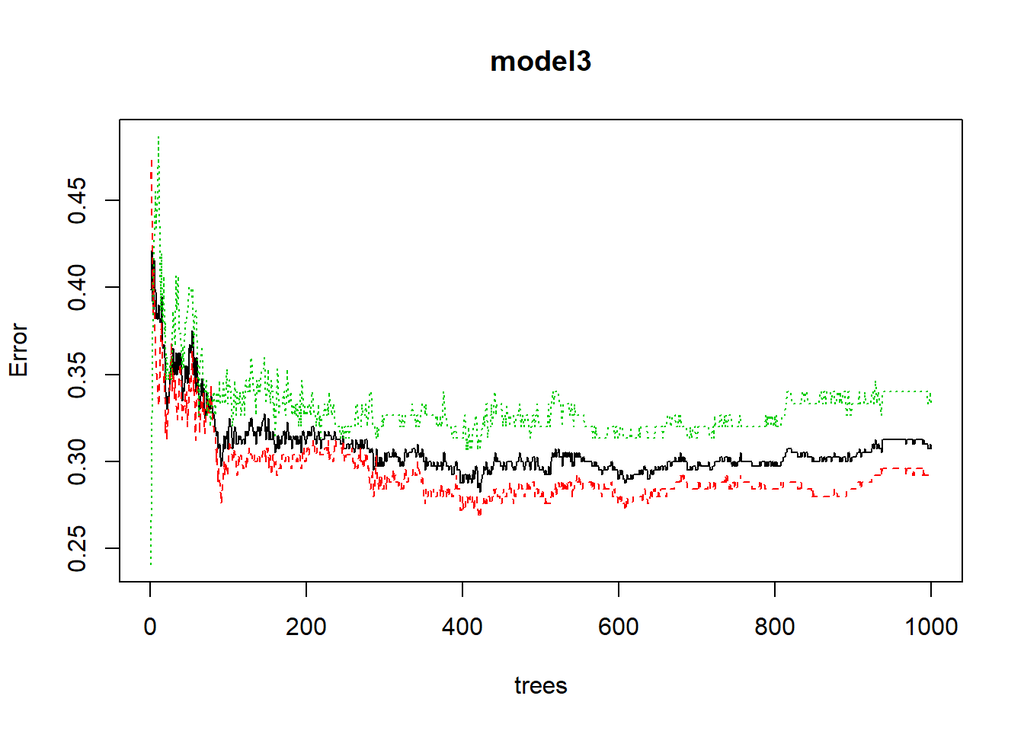

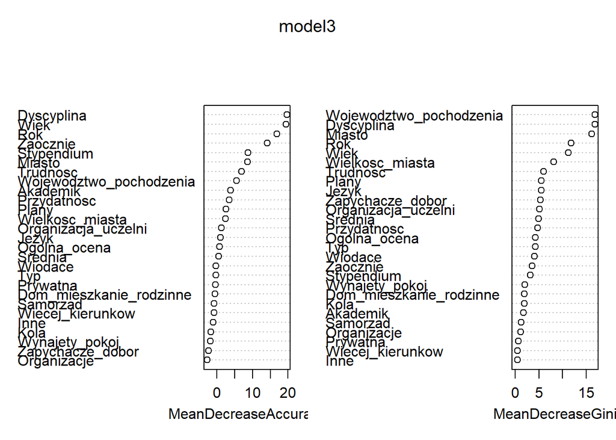

```
## AUC:  0.6873333
## OOB Error:  0.3075
## Accuracy:  0.6925
## Sensitivity:  0.708
## Specifity:  0.6666667
## G-Mean:  0.6870226
## Recall:  0.7797357
## Precision:  0.708
```

### Model oczyszczony z wątpliwych obserwacji z podziałem na dane treningowe i testowe

Podobnie jak wcześniej, przyjmuję podział 0,7:0,3.

```
##
##   0   1
## 165 115
```

```
##
## Call:
##  randomForest(formula = Praca ~ ., data = df_train2, ntree = 1000,      mtry = 5, importance = TRUE, sampsize = c(104, 104))
##                Type of random forest: classification
##                      Number of trees: 1000
## No. of variables tried at each split: 5
##
##         OOB estimate of  error rate: 31.79%
## Confusion matrix:
##     0  1 class.error
## 0 111 54   0.3272727
## 1  35 80   0.3043478
```

```
##                                   0          1 MeanDecreaseAccuracy
## Wiek                    11.35117049 15.1839259         17.648282261
## Wojewodztwo_pochodzenia  6.63935354 -5.0046376          2.635536078
## Wielkosc_miasta          0.08636009 -0.9467185         -0.516675452
## Miasto                   9.19396292 -3.3050880          6.233767422
## Wiecej_kierunkow        -1.24388888 -2.1396635         -2.125372584
## Rok                     11.36396544 16.2777401         19.215148478
## Prywatna                -1.62845805 -0.5826913         -1.547008162
## Zaocznie                 9.46917445  7.9841957         11.487831408
## Typ                     -1.89405484 -1.6610345         -2.713017701
## Kola                    -1.29729537 -1.5445926         -1.993792084
## Organizacje             -0.66534369  0.8605209         -0.005499754
## Samorzad                -2.46122234 -2.6538572         -3.525357849
## Srednia                 -3.23578116 -1.2673689         -3.474677823
## Stypendium               4.22852794  4.5474749          6.197373271
## Wiodace                 -2.75094863  2.7178849         -0.533678877
## Zapychacze_dobor        -1.21289577  2.6701710          0.738907330
## Jezyk                   -0.90113858  3.5710509          1.303160954
## Organizacja_uczelni     -2.21224172  4.2312601          0.679738863
## Plany                    1.80250023  1.8679766          2.602225462
## Trudnosc                 3.69667269  4.6396701          5.675638628
## Przydatnosc              0.30302375 -0.1457635          0.209872304
## Ogolna_ocena            -2.58311197  0.8377905         -1.709257479
## Akademik                 2.04085813 -1.2321490          0.960789643
## Dom_mieszkanie_rodzinne  0.60308687 -0.1448583          0.477528362
## Wynajety_pokoj          -2.73582943 -1.6345285         -3.122918597
## Inne                    -2.54250070 -2.0841667         -3.220490579
## Dyscyplina               8.27830453 17.0387672         16.151087389
##                         MeanDecreaseGini
## Wiek                           8.3715684
## Wojewodztwo_pochodzenia       11.2668685
## Wielkosc_miasta                5.9767450
## Miasto                        11.2412709
## Wiecej_kierunkow               0.2768786
## Rok                            9.7483836
## Prywatna                       0.4124720
## Zaocznie                       2.0221096
## Typ                            2.7196905
## Kola                           1.0603821
## Organizacje                    0.6719269
## Samorzad                       0.6732836
## Srednia                        3.1120244
## Stypendium                     1.8267463
## Wiodace                        3.1780515
## Zapychacze_dobor               4.0364543
## Jezyk                          3.7896347
## Organizacja_uczelni            3.4397637
## Plany                          3.8009072
## Trudnosc                       4.1798282
## Przydatnosc                    3.3746156
## Ogolna_ocena                   2.9296602
## Akademik                       1.1798926
## Dom_mieszkanie_rodzinne        1.3428914
## Wynajety_pokoj                 1.3441725
## Inne                           0.2135672
## Dyscyplina                    11.4613389
```

```
## AUC na danych treningowych:  0.6841897
```

```
## AUC:  0.6983193
## OOB Error:  0.3083333
## Accuracy:  0.6916667
## Sensitivity:  0.8529412
## Specifity:  0.4807692
## G-Mean:  0.6403654
## Recall:  0.6823529
## Precision:  0.8529412
```